# Optimizing Decision Boundaries

The output of most ML models is a continuous “probability” score, which must be converted into a class label by applying some kind of decision boundaries. This can be achieved in a number of ways, ranging from simple to quite complex. As an illustrative example, we will use the normal saline prediction task, with the outputs from the real-time model as the predictions, and the outputs from the retrospective model as the ground truth.

## Visual Inspection

A relatively simple approach to setting a decision boundary is to visually inspect the distribution of predicted probabilities for each class, and draw a separator where you deem the balance of sensitivity and specificity is appropriate. Below, with R, we will visualize the distributions as a standard density plot.

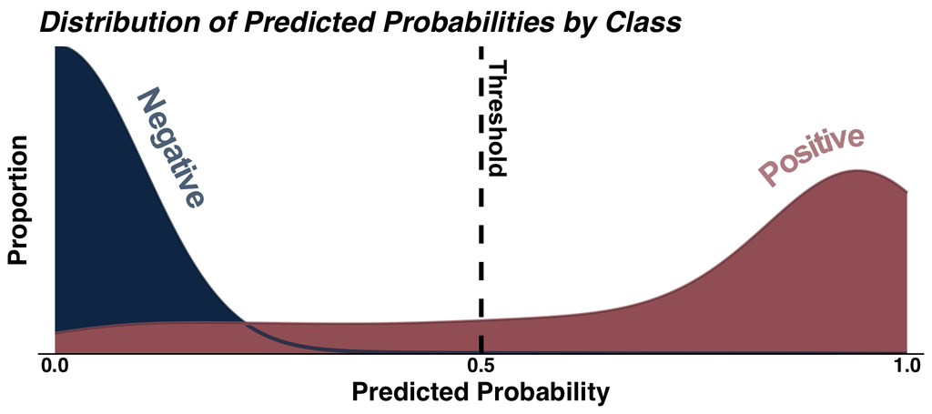

```r
suppressPackageStartupMessages(library(tidyverse))
suppressPackageStartupMessages(library(tidymodels))
options(timeout = 300)

## Load models
model_realtime <- read_rds("https://api.figshare.com/v2/file/download/45631488") |> pluck("model") |> bundle::unbundle()
model_retrospective <- read_rds("https://api.figshare.com/v2/file/download/45631491") |> pluck("model") |> bundle::unbundle()
model_realtime$fit$fit$ordered <- FALSE
model_retrospective$fit$fit$ordered <- FALSE
predictors <- model_retrospective |> extract_recipe() |> pluck("term_info") |> dplyr::filter(role == "predictor") |> pluck("variable")

## Load validation data
validation <- arrow::read_feather("https://api.figshare.com/v2/file/download/45407398") |> select(any_of(predictors))
validation_no_NA <- validation |> drop_na(matches("prior|post|potassium"))

## Make predictions using real-time model
validation_predictions <-
  bind_cols(
    validation_no_NA,
    predicted_probability = predict(model_realtime, new_data = validation_no_NA, type = "prob") |> pluck(".pred_1"),
    ground_truth = factor(predict(model_retrospective, new_data = validation_no_NA, type = "class") |> pluck(".pred_class"), labels = c("Negative", "Positive"))
    ) |>
  mutate(predicted_class = factor(ifelse(predicted_probability > 0.5, "Positive", "Negative")))

## Calculate performance metrics at a threshold of 0.5
sens <- sensitivity(validation_predictions, estimate = predicted_class, truth = ground_truth, event_level = "second")
spec <- specificity(validation_predictions, estimate = predicted_class, truth = ground_truth, event_level = "second")
pos_pred_value <- ppv(validation_predictions, estimate = predicted_class, truth = ground_truth, event_level = "second")
neg_pred_value <- npv(validation_predictions, estimate = predicted_class, truth = ground_truth, event_level = "second")
matthews_corr_coef <- mcc(validation_predictions, estimate = predicted_class, truth = ground_truth, event_level = "second")

## Visualizing the differences in the distributions between positive and negative classes.
gg_dist <-
  ggplot(validation_predictions, aes(x = predicted_probability, fill = ground_truth)) +
    geom_density(bw = 0.1) +
    geomtextpath::geom_textdensity(aes(label = ground_truth, color = ground_truth, hjust = ground_truth),
                                   linewidth = 1.25, alpha = 0.75, bw = 0.1,
                                   vjust = -0.5, fontface = "bold", size = 8) +
    scale_y_continuous(name = "Proportion", expand = c(0, 0), labels = NULL) +
    scale_x_continuous(name = "Predicted Probability", expand = c(0.01, 0.01), breaks = c(0, 0.5, 1)) +
    scale_discrete_manual(aes = "hjust", values = c(0.1, 0.95)) +
    scico::scale_fill_scico_d(palette = "lipari", begin = 0.1, end = 0.5) +
    scico::scale_color_scico_d(palette = "lipari", begin = 0.1, end = 0.5) +
    labs(x = "Predicted Probability", y = "Density", fill = "Ground Truth") +
    ggtitle("Distribution of Predicted Probabilities by Class") +
    theme(legend.position = "none", axis.line.y.left = element_blank())

gg_dist +
  geom_vline(xintercept = 0.5, linetype = "dashed", linewidth = 1.5) +
  annotate("text", x = 0.52, y = 3, label = "Threshold", fontface = "bold", angle = -90, size = 6)
```

### Performance Metrics

*Sens:* 0.793

*Spec:* 0.996

*PPV:* 0.547

*NPV:* 0.999

*MCC:* 0.656

## Youden’s J Index and the ROC Curve

The Receiver Operating Characteristic (ROC) curve has long been a staple in the evaluation of binary classifiers, and is another useful tool for setting a decision boundary. When using an ROC curve to establish a decision boundary, it is common to calculate the point at which the sum of sensitivity and specificity are maximized. This can be achieved by calculating Youden’s J index across multiple thresholds.

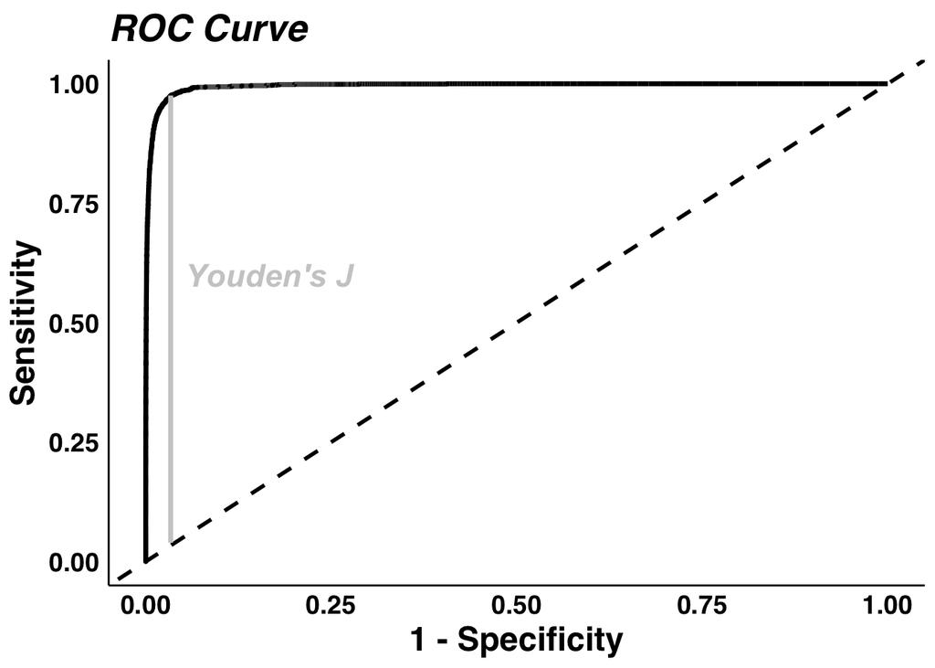

```r
## Calculate Sensitivity and Specificity Across All Thresholds
roc <-
  roc_curve(validation_predictions, predicted_probability, truth = ground_truth, event_level = "second") |>
  mutate(youden = sensitivity + specificity - 1) # Add Youden's J at each threshold

## Find the Threshold that maximizes Youden's J
threshold <- roc[which.max(roc$youden), ]

## Plot ROC Curve
ggplot(roc, aes(x = 1 - specificity, y = sensitivity)) +
  geom_step(size = 1.25) +
  geom_abline(intercept = 0, slope = 1, linetype = "dashed", color = "black", size = 1) +
  annotate("segment", x = 1 - threshold[["specificity"]], xend = 1 - threshold[["specificity"]], y = threshold[["sensitivity"]], yend = threshold[[".threshold"]], color = "grey80", linewidth = 1.25) +
  labs(x = "1 - Specificity", y = "Sensitivity") +
  annotate("text", x = 1 - threshold[["specificity"]] + 0.02, y = 0.6, label = "Youden's J", fontface = "bold.italic", color = "grey80", size = 6, hjust = 0) +
  labs(x = "1 - Specificity", y = "Sensitivity") +
  ggtitle("ROC Curve")
```

### Youden’s J Index

*Definition:*  
J = Sensitivity + Specificity - 1

*Key Consideration:*  
Maximizing Youden’s J will provide the optimal threshold *iff* **sensitivity** and **specificity** are **equally important**.

## Decision Boundaries Using Imbalance-Sensitive Metrics

Maximizing Youden’s J index works well if we care equally about sensitivity and specificity, but real-life clinical scenarios in which a false positive and a false negative are equally disruptive are rare. Additionally, the section on [Measuring Performance](https://nspies.quarto.pub/practical-machine-learning-in-the-clinical-laboratory/metric_selection.html) highlighted that metrics like sensitivity and specificity can be misleading in the setting of a class imbalance. Let’s explore how we might use metrics like the NPV, PPV, and MCC to set a decision boundary. For this, we’ll use the *{probably}<sup>1</sup>* package.

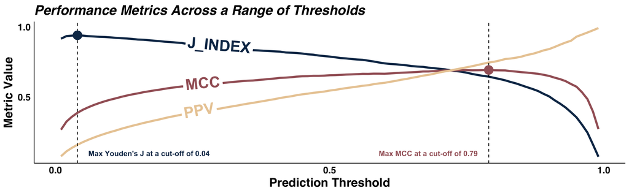

```r
library(probably)

# Define our thresholds to test
thresholds <- seq(0.01, 0.99, by = 0.01)

# Define our metrics of interest
decision_metrics <- metric_set(ppv, mcc, j_index)

# Calculate each metric across each threshold
decision_curves <-
  validation_predictions |>
  threshold_perf(truth = ground_truth, estimate = predicted_probability,
                 metrics = decision_metrics,
                 thresholds = thresholds,
                 event_level = "second")
max_mcc <- decision_curves |> dplyr::filter(.metric == "mcc") |> arrange(desc(.estimate)) |> slice_head(n = 1)
max_J <- decision_curves |> dplyr::filter(.metric == "j_index") |> arrange(desc(.estimate)) |> slice_head(n = 1)

# Plot Results
ggplot(decision_curves, aes(x = .threshold, y = .estimate, color = .metric)) +
  geomtextpath::geom_textline(aes(label = str_to_upper(.metric)), linewidth = 1.5, fontface = "bold", size = 8, hjust = 0.25) +
  geom_vline(xintercept = max_mcc[[".threshold"]], linetype = "dashed") +
  geom_text(data = max_mcc, x = max_mcc[[".threshold"]] - 0.02, y = 0.1, hjust = 1, fontface = "bold", label = glue::glue("Max MCC at a cut-off of ", max_mcc[[".threshold"]])) +
  geom_point(data = max_mcc, size = 6, aes(color = "mcc")) +
  geom_vline(xintercept = max_J[[".threshold"]], linetype = "dashed") +
  geom_text(data = max_J, x = max_J[[".threshold"]] + 0.02, y = 0.1, hjust = 0, fontface = "bold", label = glue::glue("Max Youden's J at a cut-off of ", max_J[[".threshold"]])) +
  geom_point(data = max_J, size = 6, aes(color = "j_index")) +
  scico::scale_color_scico_d(palette = "lipari", begin = 0.1, end = 0.9) +
  scale_x_continuous(name = "Prediction Threshold", breaks = c(0, 0.5, 1)) +
  scale_y_continuous(name = "Metric Value", breaks = c(0, 0.5, 1)) +
  ggtitle("Performance Metrics Across a Range of Thresholds") +
  theme(legend.position = "none")
```

Using the more imbalance-sensitive metrics, we can see that the threshold that maximizes the Matthews Correlation Coefficient (MCC) is substantially different from the threshold that maximizes Youden’s J index.

## Equivocal Zones and the No-Prediction Rate

In some clinical scenarios, where the cost of a false positive and/or a false negative prediction is high, it may be beneficial to define an “equivocal zone” where the model’s continuous output is not converted into a class prediction. This is particularly helpful when planning for fully automated implementations, where extreme confidence is needed before deciding to forgo a human review step.

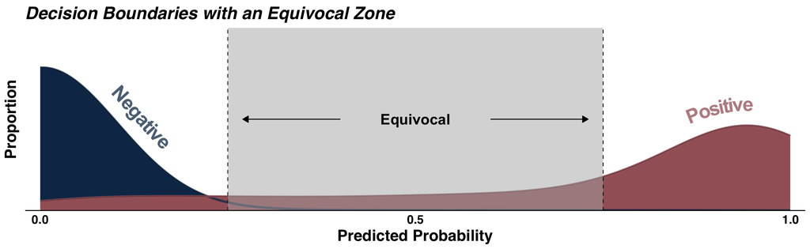

```r
gg_dist_with_equiv <-
  gg_dist +
    geom_vline(xintercept = c(0.25, 0.75), linetype = "dashed") +
    annotate("rect", xmin = 0.25, xmax = 0.75, ymin = 0, ymax = 5, fill = "gray70", alpha = 0.5) +
    annotate("text", x = 0.5, y = 2.5, label = "Equivocal", hjust = 0.5, size = 6, fontface = "bold") +
    ## Add a segment with an arrow on either side
    annotate("segment", x = 0.6, xend = 0.73, y = 2.5, yend = 2.5, arrow = arrow(type = "closed", length = unit(0.1, "inches"))) +
    annotate("segment", x = 0.4, xend = 0.27, y = 2.5, yend = 2.5, arrow = arrow(type = "closed", length = unit(0.1, "inches"))) +
    ggtitle("Decision Boundaries with an Equivocal Zone")
gg_dist_with_equiv
```

```r
# Define our equivocal zone
predictions_with_equivocal_zone <-
  validation_predictions |>
    mutate(
      .pred = make_two_class_pred(
        estimate = 1 - predicted_probability,
        levels = levels(ground_truth),
        threshold = 0.4,
        buffer = 0.25
      )
    )

# Calculate the reportable rate and performance metrics
class_metrics <- metric_set(ppv, npv, mcc)

performance_without_equivocal <- class_metrics(validation_predictions, truth = ground_truth, estimate = predicted_class, event_level = "second") |> mutate(type = "Standard", reportable_rate = 1)
performance_with_equivocal <- class_metrics(predictions_with_equivocal_zone, truth = ground_truth, estimate = .pred, event_level = "second") |> mutate(type = "With Equivocal Zone", reportable_rate = round(reportable_rate(predictions_with_equivocal_zone$.pred), digits = 3))

# Combine the results
performance <-
  bind_rows(performance_without_equivocal, performance_with_equivocal) |>
  pivot_wider(names_from = .metric, values_from = c(.estimate)) |>
  select(-.estimator)

# Print the results
performance |> knitr::kable(digits = 3)
```

| type | reportable_rate | ppv | npv | mcc |
| --- | --- | --- | --- | --- |
| Standard | 1.000 | 0.547 | 0.999 | 0.656 |
| With Equivocal Zone | 0.993 | 0.789 | 0.999 | 0.791 |

*Key Takeaway*  
The incorporation of an *Equivocal Zone* can improve performance at the cost of the proportion of results with predictions.

## References

1.

Kuhn M, Vaughan D, Ruiz E. Probably: Tools for post-processing predicted values [Internet]. 2024. Available from: https://github.com/tidymodels/probably